# embedding_visualization

```python
import numpy as np
import pandas as pd
import re
import itertools
import pickle
from gensim.models import Word2Vec
import matplotlib.pyplot as plt
from collections import defaultdict
from sklearn.manifold import TSNE,MDS,Isomap
from sklearn.decomposition import PCA
from sklearn.metrics.pairwise import cosine_similarity
from utli import read_data,searchsong
from scipy import stats
import plotly.plotly as py
import plotly.graph_objs as go
import seaborn as sns
plt.style.use('ggplot')
```

## Read Data and music2vec model

```python
user_playlist,playlist_dict,song_count,_,song_set = read_data()
m2v = Word2Vec.load("music2vec.model")
m2v50 = pd.read_csv("music2vec50.csv",index_col=0)

with open('id_playlist_dict50', 'rb') as file:
    id_playlist_dict =pickle.load(file)

#tsne embedding
df_tsne = pd.read_csv('m2v50_tsne.csv',index_col=0)

#pca embedding:
pca = PCA(n_components=2, random_state=689)
df_pca = pca.fit_transform(m2v50)
df_pca = pd.DataFrame(df_pca,index=m2v50.index)
print("PCA : explained variance ratio : {:.3f}".format(sum(pca.explained_variance_ratio_)))
```

```
PCA : explained variance ratio : 0.300
```

## Compare PCA embedding and TSNE embedding:

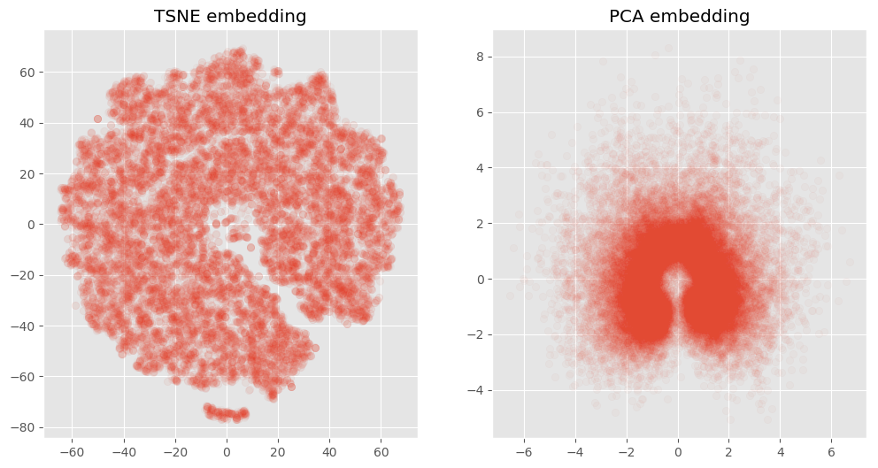

```python
plt.style.use('ggplot')
plt.figure(figsize=(12,6))
plt.subplot(121)
plt.scatter(df_tsne['0'],df_tsne['1'],alpha=0.03)
plt.title("TSNE embedding")
plt.subplot(122)
plt.scatter(df_pca[0],df_pca[1],alpha=0.03)
plt.title("PCA embedding")
plt.show()
```

### function to search playlist by name

```python
def getplaylist(keyword,ignorecase=True, dic=id_playlist_dict,n=[0,10],len_filter=[5,30]):
    '''
    search playlist in id_playlist_dict by keyword
    n: result selection. Selected like a list.
    len_filter: lower bound and upper bound for playlist length
    return : a list of ('playlistname',[songlist])
    '''
    if ignorecase:
        reg = re.compile(keyword,flags=re.IGNORECASE)
    else:
        reg = re.compile(keyword)
    res =[]
    for key,value in dic.items():
        if reg.findall(key) and len(value)>=len_filter[0] and len(value) <= len_filter[1]:
            res.append((key,value))
    sta,end = n
    if len(res)<end:
        return res[sta:]
    else:
        return res[sta:end]
```

### Song embedding:

We find the most similar songs with famous Heavy-Metal song : "Metallica - Entersandman", and draw the result in embedding results.  
These song should be clustered together if the result is good enough.

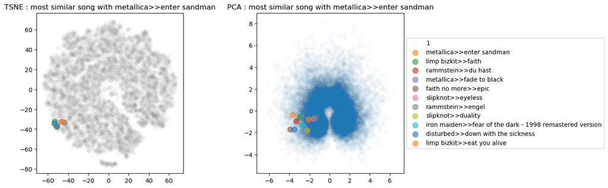

```python
res = searchsong(song_count=song_count,keyword="metallica",n=1)
sim = m2v.wv.most_similar(res[0][0])
res = res+sim

plt.figure(figsize=(12,4.8))
ax = plt.subplot(121)
ax.scatter(df_tsne['0'],df_tsne['1'],alpha=0.005)
for s in res:
    cur = df_tsne.loc[s[0],:]
    x = cur[0]
    y = cur[1]
    name = cur.name
    ax.scatter(x, y, s=80,zorder=5,alpha=0.6,label=name)
    #ax.scatter(x[0],y[0],s=100,zorder=3)
box = ax.get_position()
ax.set_position([box.x0, box.y0, box.width * 0.8, box.height])
#ax.legend(loc='center left', bbox_to_anchor=(1, 0.5))
plt.title("TSNE : most similar song with {}".format(res[0][0]))

ax = plt.subplot(122)
ax.scatter(df_pca[0],df_pca[1],alpha=0.015)
for s in res:
    cur = df_pca.loc[s[0],:]
    x = cur[0]
    y = cur[1]
    name = cur.name
    ax.scatter(x, y, s=80,zorder=5,alpha=0.6,label=name)
    #ax.scatter(x[0],y[0],s=100,zorder=3)
box = ax.get_position()
ax.set_position([box.x0, box.y0, box.width * 0.8, box.height])
ax.legend(loc='center left', bbox_to_anchor=(1, 0.5))
plt.title("PCA : most similar song with {}".format(res[0][0]))
#plt.subplot(122)
#plt.scatter(df_pca[0],df_pca[1],alpha=0.02)
#plt.title("PCA embedding")
plt.show()
```

Also, we display the famous HIP-HOP song "Love The Way You Lie" by Eminem and Rihanna, which is played 1.6 billion times in Youtube till Oct.18.

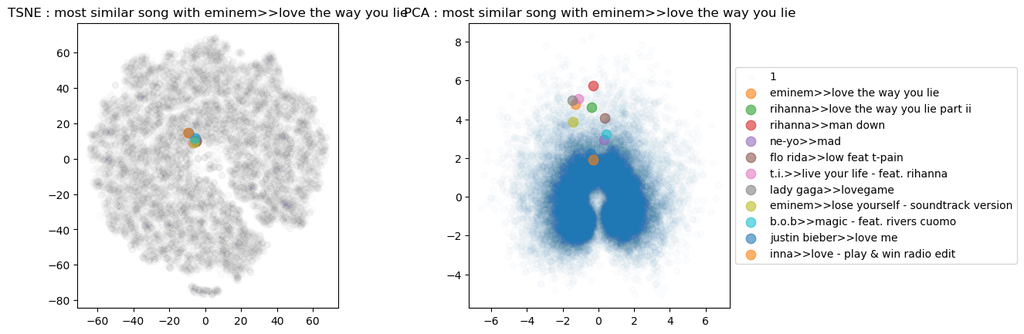

```python
res = searchsong(song_count=song_count,keyword="Eminem",n=1)
print(res)
sim = m2v.wv.most_similar(res[0][0])
res = res+sim

plt.figure(figsize=(12,4.8))
ax = plt.subplot(121)
ax.scatter(df_tsne['0'],df_tsne['1'],alpha=0.005)
for s in res:
    cur = df_tsne.loc[s[0],:]
    x = cur[0]
    y = cur[1]
    name = cur.name
    ax.scatter(x, y, s=80,zorder=5,alpha=0.6,label=name)
    #ax.scatter(x[0],y[0],s=100,zorder=3)
box = ax.get_position()
ax.set_position([box.x0, box.y0, box.width * 0.8, box.height])
#ax.legend(loc='center left', bbox_to_anchor=(1, 0.5))
plt.title("TSNE : most similar song with {}".format(res[0][0]))

ax = plt.subplot(122)
ax.scatter(df_pca[0],df_pca[1],alpha=0.015)
for s in res:
    cur = df_pca.loc[s[0],:]
    x = cur[0]
    y = cur[1]
    name = cur.name
    ax.scatter(x, y, s=80,zorder=5,alpha=0.6,label=name)
    #ax.scatter(x[0],y[0],s=100,zorder=3)
box = ax.get_position()
ax.set_position([box.x0, box.y0, box.width * 0.8, box.height])
ax.legend(loc='center left', bbox_to_anchor=(1, 0.5))
plt.title("PCA : most similar song with {}".format(res[0][0]))
#plt.subplot(122)
#plt.scatter(df_pca[0],df_pca[1],alpha=0.02)
#plt.title("PCA embedding")
plt.show()
```

It seems TSNE's performance is better than PCA.

### Embeddings for songs by same artist : Oasis

Oasis is the leading band in genre british-rock(英式搖滾). The embedding of there most-played 10 songs is plotted below.  
These songs should be closed to each other, but ...

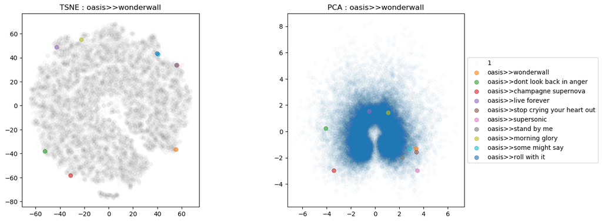

```python
plt.style.use('default')
res = searchsong(song_count=song_count,keyword="oasis",n=10)
plt.figure(figsize=(14,5.6))
ax = plt.subplot(121)
ax.scatter(df_tsne['0'],df_tsne['1'],alpha=0.005,label='_nolegend_')
for s in res:
    cur = df_tsne.loc[s[0],:]
    x = cur[0]
    y = cur[1]
    name = cur.name
    ax.scatter(x, y, s=40,zorder=5,alpha=0.6,label=name)
    #ax.scatter(x[0],y[0],s=100,zorder=3)
box = ax.get_position()
ax.set_position([box.x0, box.y0, box.width * 0.8, box.height])
#ax.legend(loc='center left', bbox_to_anchor=(1, 0.5))
plt.title("TSNE : {}".format(res[0][0]))
ax = plt.subplot(122)
ax.scatter(df_pca[0],df_pca[1],alpha=0.015)
for s in res:
    cur = df_pca.loc[s[0],:]
    x = cur[0]
    y = cur[1]
    name = cur.name
    ax.scatter(x, y, s=40,zorder=5,alpha=0.6,label=name)
    #ax.scatter(x[0],y[0],s=100,zorder=3)
box = ax.get_position()
ax.set_position([box.x0, box.y0, box.width * 0.8, box.height])
ax.legend(loc='center left', bbox_to_anchor=(1, 0.5))
plt.title("PCA : {}".format(res[0][0]))
#plt.subplot(122)
#plt.scatter(df_pca[0],df_pca[1],alpha=0.02)
#plt.title("PCA embedding")
plt.savefig("oasis.jpg")
plt.show()
```

For top-10 Megadeth songs:

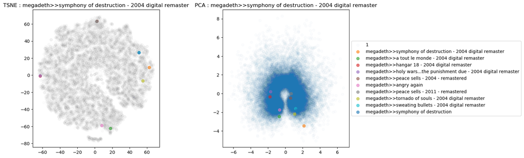

```python
plt.style.use('default')
res = searchsong(song_count=song_count,keyword="megadeth",n=10)
plt.figure(figsize=(14,5.6))
ax = plt.subplot(121)
ax.scatter(df_tsne['0'],df_tsne['1'],alpha=0.005,label='_nolegend_')
for s in res:
    cur = df_tsne.loc[s[0],:]
    x = cur[0]
    y = cur[1]
    name = cur.name
    ax.scatter(x, y, s=40,zorder=5,alpha=0.6,label=name)
    #ax.scatter(x[0],y[0],s=100,zorder=3)
box = ax.get_position()
ax.set_position([box.x0, box.y0, box.width * 0.8, box.height])
#ax.legend(loc='center left', bbox_to_anchor=(1, 0.5))
plt.title("TSNE : {}".format(res[0][0]))
ax = plt.subplot(122)
ax.scatter(df_pca[0],df_pca[1],alpha=0.015)
for s in res:
    cur = df_pca.loc[s[0],:]
    x = cur[0]
    y = cur[1]
    name = cur.name
    ax.scatter(x, y, s=40,zorder=5,alpha=0.6,label=name)
    #ax.scatter(x[0],y[0],s=100,zorder=3)
box = ax.get_position()
ax.set_position([box.x0, box.y0, box.width * 0.8, box.height])
ax.legend(loc='center left', bbox_to_anchor=(1, 0.5))
plt.title("PCA : {}".format(res[0][0]))
#plt.subplot(122)
#plt.scatter(df_pca[0],df_pca[1],alpha=0.02)
#plt.title("PCA embedding")
plt.savefig("oasis.jpg")
plt.show()
```

From above, song embedding does not perform as expected.

Oasis 與 Megadeth 分別是英式搖滾與鞭笞金屬(thrash metal)兩種次曲風(subgenre)的知名樂團。與流行歌手不同，這些次曲風樂團的特色是歌曲間曲風變化小，相似度高，聽眾也多為該曲風的愛好者，因此同創作者的歌曲應該要有相似的embedding結果。

或者說，在embedding的向量空間中有較高的相似性(cosine similarity)。但從TSNE與PCA的低維視覺化結果來看，結果卻不如預期。

接著我們來看看cosine 矩陣：

```python
def plot_cosine(name):
    res = searchsong(song_count=song_count,keyword=name,n=10)
    vec = [m2v.wv.get_vector(item[0]) for item in res]
    df = pd.DataFrame(cosine_similarity(vec),index=[item[0] for item in res])
    df.index.name = "Cosine Similarity"
    df
    plt.figure(figsize=(9,6))
    #sns.set()
    ax = sns.heatmap(df,annot=True,cmap="YlGnBu",)
    ax.tick_params(labelsize=14)
    ax.set_title("Top {} Song's Similarity".format(name),fontsize=20)
```

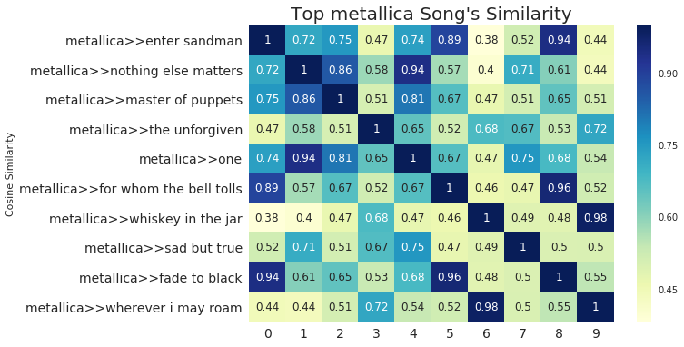

```python
plot_cosine("metallica")
```

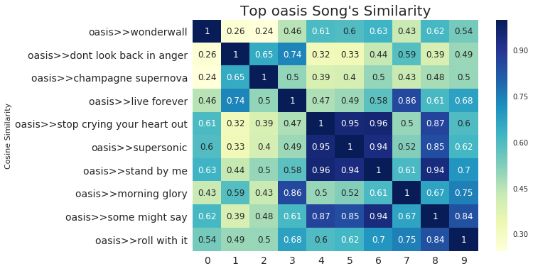

```python
plot_cosine("oasis")
```

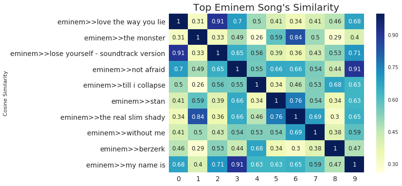

```python
plot_cosine("Eminem")
```

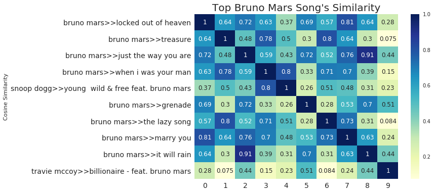

```python
plot_cosine("Bruno Mars")
```

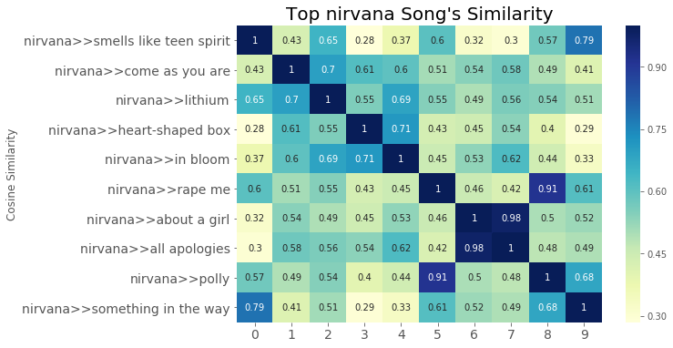

```python
plot_cosine("nirvana")
```

## plot playlist:

draw playlist as series in two-dim embedding space.

### Matplotlib

```python
def getplaylist_xy(search_res,embedding_df=df_tsne):
    X=[];Y=[];pname = search_res[0];sname=search_res[1]
    for i,j in enumerate(search_res[1]):
        x,y = embedding_df.loc[j,:]
        X.append(x)
        Y.append(y)
    return pname,sname,X,Y

def plotplaylist(res):
    fig = plt.figure(figsize=(8, 6.4))
    ax = plt.subplot(111)
    plt.xlim(xmin-2,xmax+2)
    plt.ylim(ymin-2,ymax+2)
    plt.scatter(df_tsne['0'],df_tsne['1'],alpha=0.01,label='_nolegend_')
    for i in res:
        pname,sname,x,y = getplaylist_xy(i)
        ax.plot(x, y, 'grey', zorder=1, lw=1)
        ax.scatter(x, y,s=30,alpha=0.8, zorder=2,label=re.split(">>",pname)[1])
        #ax.scatter(x[0],y[0],s=100,zorder=3)
    box = ax.get_position()
    ax.set_position([box.x0, box.y0, box.width * 0.8, box.height])
    # Put a legend to the right of the current axis
    ax.legend(title="Playlist",loc='center left', bbox_to_anchor=(1, 0.5))
    plt.title("playlist embedding")
    plt.show()
```

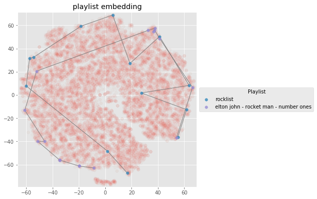

```python
xmin,ymin = df_tsne.describe().loc["min",].values
xmax,ymax = df_tsne.describe().loc["max",].values
res = getplaylist("rock",n=[14,16])
plotplaylist(res)
```

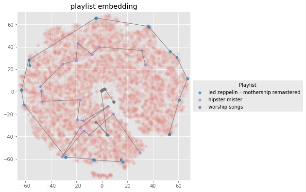

```python
res = getplaylist("hip",n=[13,16])
plotplaylist(res)
```

### Plotly

也畫一下熱點圖，比較歌之間的相似度

#### Rock Playlist

```
Text(0.5,1,"Playlist: rock fm 500 Song's Similarity")
```

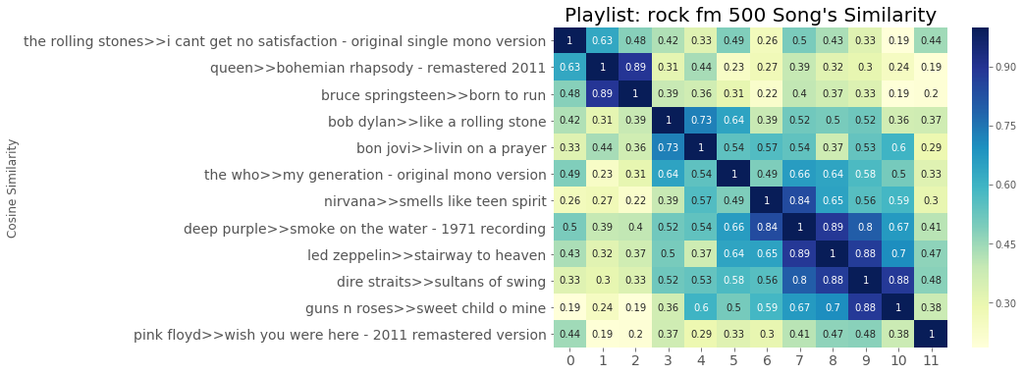

```python
res = getplaylist("rock",n=[17,18])
vec = [m2v.wv.get_vector(item) for item in res[0][1]]
df = pd.DataFrame(cosine_similarity(vec),index=[item for item in res[0][1]])
df.index.name = "Cosine Similarity"
df
plt.figure(figsize=(9,6))
#sns.set()
ax = sns.heatmap(df,annot=True,cmap="YlGnBu",)
ax.tick_params(labelsize=14)
ax.set_title("Playlist: {} Song's Similarity".format(res[0][0].split(">>")[1]),fontsize=20)
```

```python
res = getplaylist("rock",n=[17,18])
pname,sname,x,y = getplaylist_xy(res[0])
trace0 = go.Scatter(
    x=df_tsne['0'].values,
    y=df_tsne['1'].values,
    text= df_tsne.index,
    mode='markers',
    name = 'song embeddings',
    marker= dict(size= 8,
                line= dict(width=1),
                opacity= 0.05
                )
)
trace1 = go.Scatter(
    x = x,
    y = y,
    text=sname,
    textposition='bottom center',
    mode = 'lines+markers',
    name="playlist",
    marker = dict(
        size = 10,
        color = 'rgba(152, 0, 0, .5)',
        line = dict(
            width = 2,
            color = 'rgb(0, 0, 0)'
        )
    )
)
data = [trace0,trace1]
layout = dict(title = pname.split(">>")[1],
              #width=1400,
              #height=900,
              hovermode= 'closest',
              xaxis = dict(zeroline = False,
                           #autorange= False,
                          range=[xmin, xmax]),
              yaxis = dict(zeroline = False,
                           #autorange= False,
                           scaleanchor='x',
                           scaleratio=1,
                           range =[ymin,ymax]
                          )
             # annotations= [{'x':x,'y':y,'text':t,'showarrow':False,'yshift':10,'xshift':10,'font':dict(size =18)} for x,y,t in zip(x,y,range(1,len(y)+1))]
             )
updatemenus=list([
    dict(
        buttons=list([
            dict(
                args=[{'visible': [True,True]}],
                label='Both',
                method='restyle'
            ),
            dict(
                args=[{'visible': [False,True]}],
                label='Playlist',
                method='restyle'
            ),
            dict(
                args=[{'visible': [True,False]}],
                label='Song Embeddings',
                method='restyle'
            )
        ]),
        direction = 'left',
        pad = {'r': 10, 't': 10},
        showactive = True,
        type = 'buttons',
        x = 0.1,
        xanchor = 'left',
        y = 1.1,
        yanchor = 'top'
    ),
])

buttuon_annotations = list([
    dict(text='Display',x=0,y=1.1,xref='paper', yref='paper',font=dict(size =16), align='left', showarrow=False)
])
playlist_annotations = list([
    {'x':x,'y':y,'text':t,'showarrow':False,'yshift':10,'xshift':10,'font':dict(size =18)} for x,y,t in zip(x,y,range(1,len(y)+1))
])

layout['updatemenus'] = updatemenus
layout['annotations'] = buttuon_annotations + playlist_annotations

fig = dict(data=data, layout=layout)
py.iplot(fig, filename=pname)
```

[interactive chart not shown]

#### SAD song playlist

```python
res = getplaylist("sad ",n=[0,1])
pname,sname,x,y = getplaylist_xy(res[0])

trace1 = go.Scatter(
    x = x,
    y = y,
    text=sname,
    textposition='bottom center',
    mode = 'lines+markers',
    name="playlist",
    marker = dict(
        size = 10,
        color = 'rgba(152, 0, 0, .5)',
        line = dict(
            width = 2,
            color = 'rgb(0, 0, 0)'
        )
    )
)
data = [trace1]
layout = dict(title = pname.split(">>")[1],
              #width=1400,
              #height=900,
              hovermode= 'closest',
              xaxis = dict(zeroline = False,
                           #autorange= False,
                          range=[xmin, xmax]),
              yaxis = dict(zeroline = False,
                           #autorange= False,
                           scaleanchor='x',
                           scaleratio=1,
                           range =[ymin,ymax]
                          )
             # annotations= [{'x':x,'y':y,'text':t,'showarrow':False,'yshift':10,'xshift':10,'font':dict(size =18)} for x,y,t in zip(x,y,range(1,len(y)+1))]
             )

playlist_annotations = list([
    {'x':x,'y':y,'text':t,'showarrow':False,'yshift':10,'xshift':10,'font':dict(size =18)} for x,y,t in zip(x,y,range(1,len(y)+1))
])
layout['annotations'] = playlist_annotations

fig = dict(data=data, layout=layout)
py.iplot(fig, filename=pname)
```

[interactive chart not shown]

```
Text(0.5,1,"Playlist: sad songs say so much Song's Similarity")
```

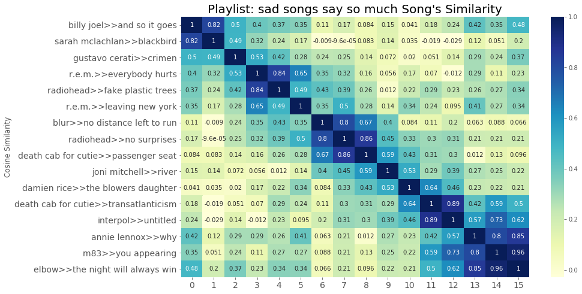

```python
vec = [m2v.wv.get_vector(item) for item in res[0][1]]
df = pd.DataFrame(cosine_similarity(vec),index=[item for item in res[0][1]])
df.index.name = "Cosine Similarity"
df
plt.figure(figsize=(13,8))
#sns.set()
ax = sns.heatmap(df,annot=True,cmap="YlGnBu",)
ax.tick_params(labelsize=14)
ax.set_title("Playlist: {} Song's Similarity".format(res[0][0].split(">>")[1]),fontsize=20)
```